# Fitbit_Analysis

Rita Munoz

11/1/2022

## Case Scenario

You are a junior data analyst working on the marketing analyst team at Bellabeat, a high-tech manufacturer of health-focused products for women. Bellabeat is a successful small company, but they have the potential to become a larger player in the global smart device market. Urška Sršen, cofounder and Chief Creative Officer of Bellabeat, believes that analyzing smart device fitness data could help unlock new growth opportunities for the company. You have been asked to focus on one of Bellabeat’s products and analyze smart device data to gain insight into how consumers are using their smart devices. The insights you discover will then help guide marketing strategy for the company. You will present your analysis to the Bellabeat executive team along with your high-level recommendations for Bellabeat’s marketing strategy.

## Characters and Products

- **Characters**
  - **Urška Sršen:** Bellabeat’s cofounder and Chief Creative Officer
  - **Sando Mur:** Mathematician and Bellabeat’s cofounder; key member of the Bellabeat executive team
  - **Bellabeat marketing analytics team:** A team of data analysts responsible for collecting, analyzing, and reporting data that helps guide Bellabeat’s marketing strategy. You joined this team six months ago and have been busy learning about Bellabeat’’s mission and business goals — as well as how you, as a junior data analyst, can help Bellabeat achieve them.
- **Products**
  - **Bellabeat app:** The Bellabeat app provides users with health data related to their activity, sleep, stress, menstrual cycle, and mindfulness habits. This data can help users better understand their current habits and make healthy decisions. The Bellabeat app connects to their line of smart wellness products.
  - **Leaf:** Bellabeat’s classic wellness tracker can be worn as a bracelet, necklace, or clip. The Leaf tracker connects to the Bellabeat app to track activity, sleep, and stress.
  - **Time:** This wellness watch combines the timeless look of a classic timepiece with smart technology to track user activity, sleep, and stress. The Time watch connects to the Bellabeat app to provide you with insights into your daily wellness.
  - **Spring:** This is a water bottle that tracks daily water intake using smart technology to ensure that you are appropriately hydrated throughout the day. The Spring bottle connects to the Bellabeat app to track your hydration levels.
  - **Bellabeat membership:** Bellabeat also offers a subscription-based membership program for users. Membership gives users 24/7 access to fully personalized guidance on nutrition, activity, sleep, health and beauty, and mindfulness based on their lifestyle and goals.

Sršen asks you to analyze smart device usage data in order to gain insight into how consumers use non-Bellabeat smart devices. She then wants you to select one Bellabeat product to apply these insights to in your presentation. These questions will guide your analysis:

- 1. What are some trends in smart device usage?
- 2. How could these trends apply to Bellabeat customers?
- 3. How could these trends help influence Bellabeat marketing strategy?

## Index

- 1. A clear summary of the business task
- 2. A description of all data sources used
- 3. Documentation of any cleaning or manipulation of data
- 4. A summary of your analysis
- 5. Supporting visualizations and key findings
- 6. Your top high-level content recommendations based on your analysis

## 1. Summary of business task

Identify trends in smart devices usage to understand the market needs in order to plan the Bellabeat’s Marketing strategy accordingly.

## 2. Description of all data sources used

The data used in this analysis is recommended from one of the stakeholders and is the FitBit Fitness Tracker Data set at Kaggle. The data is public domain and is eligible to be copied, modified, and/or distributed without having to ask for the owner’s permission.

## 4. A summary of your analysis

```r
#install.packages("tidyverse")
#require(tidyverse)
#install.packages("lubridate")
#install.packages("janitor")

library(tidyverse)
library(lubridate)
library(dplyr)
library(ggplot2)
library(tidyr)
library(janitor)
library(dplyr)
```

```r
activity <- read.csv("~/Desktop/Programming/Python/Google - Data Analytics/Fitabase Case/Data sets/dailyactivity.csv")
calories <- read.csv("~/Desktop/Programming/Python/Google - Data Analytics/Fitabase Case/Data sets/dailycalories.csv")
heart <- read.csv("~/Desktop/Programming/Python/Google - Data Analytics/Fitabase Case/Data sets/heartrateseconds.csv")
sleep <- read.csv("~/Desktop/Programming/Python/Google - Data Analytics/Fitabase Case/Data sets/sleep.csv")
weight <- read.csv("~/Desktop/Programming/Python/Google - Data Analytics/Fitabase Case/Data sets/weight.csv")
steps <- read.csv("~/Desktop/Programming/Python/Google - Data Analytics/Fitabase Case/Data sets/dailysteps.csv")
```

[output not shown]

[output not shown]

[output not shown]

[output not shown]

[output not shown]

[output not shown]

```r
# Checking for Unique IDs, na.rm = TRUE >> missing values do not count
n_distinct(activity$Id, na.rm = TRUE)
```

```
## [1] 33
```

```r
n_distinct(calories$Id)
```

```
## [1] 33
```

```r
n_distinct(heart$Id)
```

```
## [1] 14
```

```r
n_distinct(sleep$Id)
```

```
## [1] 24
```

```r
n_distinct(weight$Id)
```

```
## [1] 8
```

```r
n_distinct(steps$Id)
```

```
## [1] 33
```

```r
sum(duplicated(activity))
```

```
## [1] 0
```

```r
sum(duplicated(calories))
```

```
## [1] 0
```

```r
sum(duplicated(heart))
```

```
## [1] 0
```

```r
sum(duplicated(sleep))
```

```
## [1] 3
```

```r
sleep1 <- unique(sleep)
sum(duplicated(sleep1))
```

```
## [1] 0
```

```r
sum(duplicated(weight))
```

```
## [1] 0
```

```r
sum(duplicated(steps))
```

```
## [1] 0
```

```r
activity <- activity %>%
  mutate(DATE1 = mdy(ActivityDate))

calories <- calories %>%
  mutate(DATE1 = mdy(ActivityDay))

#heart <- heart %>%
#  mutate(DATE = as_date(Time, format = "%d/%m/%Y"))

heart <- heart %>%
  mutate(DATE1 = as.Date(Time, format = "%m/%d/%Y"))

# CORRECT WAY TO CHANGE TO A DATE FORMAT, THE 'format=' REFERS TO THE FORMAT THE COLUMN IS BY DEFAULT NOT TO WHICH YOU WANT TO CHANGE IT INTO
#heart <- heart %>%
#  mutate(DATE_asDate = as.Date(Time, format = "%m/%d/%Y", tz=""))

head(heart)
```

```
##           Id                 Time Value      DATE1
## 1 2022484408 4/12/2016 7:21:00 AM    97 2016-04-12
## 2 2022484408 4/12/2016 7:21:05 AM   102 2016-04-12
## 3 2022484408 4/12/2016 7:21:10 AM   105 2016-04-12
## 4 2022484408 4/12/2016 7:21:20 AM   103 2016-04-12
## 5 2022484408 4/12/2016 7:21:25 AM   101 2016-04-12
## 6 2022484408 4/12/2016 7:22:05 AM    95 2016-04-12
```

```r
sleep1 <- sleep1 %>%
  mutate(DATE = mdy_hms(SleepDay))

sleep1 <- sleep1 %>%
  mutate(DATE1 = as.Date(as.POSIXct(DATE), tz=""))

weight <- weight %>%
  mutate(DATE = mdy_hms(Date))

weight <- weight %>%
  mutate(DATE1 = as.Date(as.POSIXct(DATE), tz=""))

steps <- steps %>%
   mutate(DATE1 = mdy(ActivityDay))
```

```r
head(activity)
```

```
##           Id ActivityDate TotalSteps TotalDistance TrackerDistance
## 1 1503960366    4/12/2016      13162          8.50            8.50
## 2 1503960366    4/13/2016      10735          6.97            6.97
## 3 1503960366    4/14/2016      10460          6.74            6.74
## 4 1503960366    4/15/2016       9762          6.28            6.28
## 5 1503960366    4/16/2016      12669          8.16            8.16
## 6 1503960366    4/17/2016       9705          6.48            6.48
##   LoggedActivitiesDistance VeryActiveDistance ModeratelyActiveDistance
## 1                        0               1.88                     0.55
## 2                        0               1.57                     0.69
## 3                        0               2.44                     0.40
## 4                        0               2.14                     1.26
## 5                        0               2.71                     0.41
## 6                        0               3.19                     0.78
##   LightActiveDistance SedentaryActiveDistance VeryActiveMinutes
## 1                6.06                       0                25
## 2                4.71                       0                21
## 3                3.91                       0                30
## 4                2.83                       0                29
## 5                5.04                       0                36
## 6                2.51                       0                38
##   FairlyActiveMinutes LightlyActiveMinutes SedentaryMinutes Calories      DATE1
## 1                  13                  328              728     1985 2016-04-12
## 2                  19                  217              776     1797 2016-04-13
## 3                  11                  181             1218     1776 2016-04-14
## 4                  34                  209              726     1745 2016-04-15
## 5                  10                  221              773     1863 2016-04-16
## 6                  20                  164              539     1728 2016-04-17
```

```r
head(calories)
```

```
##           Id ActivityDay Calories      DATE1
## 1 1503960366   4/12/2016     1985 2016-04-12
## 2 1503960366   4/13/2016     1797 2016-04-13
## 3 1503960366   4/14/2016     1776 2016-04-14
## 4 1503960366   4/15/2016     1745 2016-04-15
## 5 1503960366   4/16/2016     1863 2016-04-16
## 6 1503960366   4/17/2016     1728 2016-04-17
```

```r
head(heart)
```

```
##           Id                 Time Value      DATE1
## 1 2022484408 4/12/2016 7:21:00 AM    97 2016-04-12
## 2 2022484408 4/12/2016 7:21:05 AM   102 2016-04-12
## 3 2022484408 4/12/2016 7:21:10 AM   105 2016-04-12
## 4 2022484408 4/12/2016 7:21:20 AM   103 2016-04-12
## 5 2022484408 4/12/2016 7:21:25 AM   101 2016-04-12
## 6 2022484408 4/12/2016 7:22:05 AM    95 2016-04-12
```

```r
head(sleep1)
```

```
##           Id              SleepDay TotalSleepRecords TotalMinutesAsleep
## 1 1503960366 4/12/2016 12:00:00 AM                 1                327
## 2 1503960366 4/13/2016 12:00:00 AM                 2                384
## 3 1503960366 4/15/2016 12:00:00 AM                 1                412
## 4 1503960366 4/16/2016 12:00:00 AM                 2                340
## 5 1503960366 4/17/2016 12:00:00 AM                 1                700
## 6 1503960366 4/19/2016 12:00:00 AM                 1                304
##   TotalTimeInBed       DATE      DATE1
## 1            346 2016-04-12 2016-04-11
## 2            407 2016-04-13 2016-04-12
## 3            442 2016-04-15 2016-04-14
## 4            367 2016-04-16 2016-04-15
## 5            712 2016-04-17 2016-04-16
## 6            320 2016-04-19 2016-04-18
```

```r
head(weight)
```

```
##           Id                  Date WeightKg WeightPounds Fat   BMI
## 1 1503960366  5/2/2016 11:59:59 PM     52.6     115.9631  22 22.65
## 2 1503960366  5/3/2016 11:59:59 PM     52.6     115.9631  NA 22.65
## 3 1927972279  4/13/2016 1:08:52 AM    133.5     294.3171  NA 47.54
## 4 2873212765 4/21/2016 11:59:59 PM     56.7     125.0021  NA 21.45
## 5 2873212765 5/12/2016 11:59:59 PM     57.3     126.3249  NA 21.69
## 6 4319703577 4/17/2016 11:59:59 PM     72.4     159.6147  25 27.45
##   IsManualReport        LogId                DATE      DATE1
## 1           True 1.462234e+12 2016-05-02 23:59:59 2016-05-02
## 2           True 1.462320e+12 2016-05-03 23:59:59 2016-05-03
## 3          False 1.460510e+12 2016-04-13 01:08:52 2016-04-12
## 4           True 1.461283e+12 2016-04-21 23:59:59 2016-04-21
## 5           True 1.463098e+12 2016-05-12 23:59:59 2016-05-12
## 6           True 1.460938e+12 2016-04-17 23:59:59 2016-04-17
```

```r
head(steps)
```

```
##           Id ActivityDay StepTotal      DATE1
## 1 1503960366   4/12/2016     13162 2016-04-12
## 2 1503960366   4/13/2016     10735 2016-04-13
## 3 1503960366   4/14/2016     10460 2016-04-14
## 4 1503960366   4/15/2016      9762 2016-04-15
## 5 1503960366   4/16/2016     12669 2016-04-16
## 6 1503960366   4/17/2016      9705 2016-04-17
```

```r
#str(activity)

#activity <- as.data.frame.matrix(activity)

#str(activity)

activity %>%
  select(TotalSteps,
         TotalDistance,
         VeryActiveMinutes,
         FairlyActiveMinutes,
         LightlyActiveMinutes,
         SedentaryMinutes,
         Calories) %>%
  summary()
```

```
##    TotalSteps    TotalDistance    VeryActiveMinutes FairlyActiveMinutes
##  Min.   :    0   Min.   : 0.000   Min.   :  0.00    Min.   :  0.00
##  1st Qu.: 3790   1st Qu.: 2.620   1st Qu.:  0.00    1st Qu.:  0.00
##  Median : 7406   Median : 5.245   Median :  4.00    Median :  6.00
##  Mean   : 7638   Mean   : 5.490   Mean   : 21.16    Mean   : 13.56
##  3rd Qu.:10727   3rd Qu.: 7.713   3rd Qu.: 32.00    3rd Qu.: 19.00
##  Max.   :36019   Max.   :28.030   Max.   :210.00    Max.   :143.00
##  LightlyActiveMinutes SedentaryMinutes    Calories
##  Min.   :  0.0        Min.   :   0.0   Min.   :   0
##  1st Qu.:127.0        1st Qu.: 729.8   1st Qu.:1828
##  Median :199.0        Median :1057.5   Median :2134
##  Mean   :192.8        Mean   : 991.2   Mean   :2304
##  3rd Qu.:264.0        3rd Qu.:1229.5   3rd Qu.:2793
##  Max.   :518.0        Max.   :1440.0   Max.   :4900
```

```r
heart %>%
  select(Value) %>%
  summary()
```

```
##      Value
##  Min.   : 36.00
##  1st Qu.: 63.00
##  Median : 73.00
##  Mean   : 77.33
##  3rd Qu.: 88.00
##  Max.   :203.00
```

```r
sleep1 %>%
  select(TotalMinutesAsleep,
         TotalTimeInBed) %>%
  summary()
```

```
##  TotalMinutesAsleep TotalTimeInBed
##  Min.   : 58.0      Min.   : 61.0
##  1st Qu.:361.0      1st Qu.:403.8
##  Median :432.5      Median :463.0
##  Mean   :419.2      Mean   :458.5
##  3rd Qu.:490.0      3rd Qu.:526.0
##  Max.   :796.0      Max.   :961.0
```

```r
weight %>%
  select(WeightKg,
         WeightPounds,
         Fat,
         BMI) %>%
  summary()
```

```
##     WeightKg       WeightPounds        Fat             BMI
##  Min.   : 52.60   Min.   :116.0   Min.   :22.00   Min.   :21.45
##  1st Qu.: 61.40   1st Qu.:135.4   1st Qu.:22.75   1st Qu.:23.96
##  Median : 62.50   Median :137.8   Median :23.50   Median :24.39
##  Mean   : 72.04   Mean   :158.8   Mean   :23.50   Mean   :25.19
##  3rd Qu.: 85.05   3rd Qu.:187.5   3rd Qu.:24.25   3rd Qu.:25.56
##  Max.   :133.50   Max.   :294.3   Max.   :25.00   Max.   :47.54
##                                   NA's   :65
```

### 4.2 Merging Data

```r
sleep_activity_merged <- activity %>% right_join(sleep1, by=c("Id","DATE1"))
head(sleep_activity_merged)
```

```
##           Id ActivityDate TotalSteps TotalDistance TrackerDistance
## 1 1503960366    4/12/2016      13162          8.50            8.50
## 2 1503960366    4/14/2016      10460          6.74            6.74
## 3 1503960366    4/15/2016       9762          6.28            6.28
## 4 1503960366    4/16/2016      12669          8.16            8.16
## 5 1503960366    4/18/2016      13019          8.59            8.59
## 6 1503960366    4/19/2016      15506          9.88            9.88
##   LoggedActivitiesDistance VeryActiveDistance ModeratelyActiveDistance
## 1                        0               1.88                     0.55
## 2                        0               2.44                     0.40
## 3                        0               2.14                     1.26
## 4                        0               2.71                     0.41
## 5                        0               3.25                     0.64
## 6                        0               3.53                     1.32
##   LightActiveDistance SedentaryActiveDistance VeryActiveMinutes
```

[output cut: 27 more lines]

```r
#head(activity)
#head(sleep1)

head(sleep_activity_merged)
```

```
##           Id ActivityDate TotalSteps TotalDistance TrackerDistance
## 1 1503960366    4/12/2016      13162          8.50            8.50
## 2 1503960366    4/14/2016      10460          6.74            6.74
## 3 1503960366    4/15/2016       9762          6.28            6.28
## 4 1503960366    4/16/2016      12669          8.16            8.16
## 5 1503960366    4/18/2016      13019          8.59            8.59
## 6 1503960366    4/19/2016      15506          9.88            9.88
##   LoggedActivitiesDistance VeryActiveDistance ModeratelyActiveDistance
## 1                        0               1.88                     0.55
## 2                        0               2.44                     0.40
## 3                        0               2.14                     1.26
## 4                        0               2.71                     0.41
## 5                        0               3.25                     0.64
## 6                        0               3.53                     1.32
##   LightActiveDistance SedentaryActiveDistance VeryActiveMinutes
```

[output cut: 27 more lines]

```r
average_daily <- activity %>%
  group_by(Id) %>%
  summarize(mean_daily_steps = mean(TotalSteps), mean_daily_calories = mean(Calories))

head(average_daily)
```

```
## # A tibble: 6 × 3
##           Id mean_daily_steps mean_daily_calories
##        <dbl>            <dbl>               <dbl>
## 1 1503960366           12117.               1816.
## 2 1624580081            5744.               1483.
## 3 1644430081            7283.               2811.
## 4 1844505072            2580.               1573.
## 5 1927972279             916.               2173.
## 6 2022484408           11371.               2510.
```

## 5. Supporting visualizations and key findings

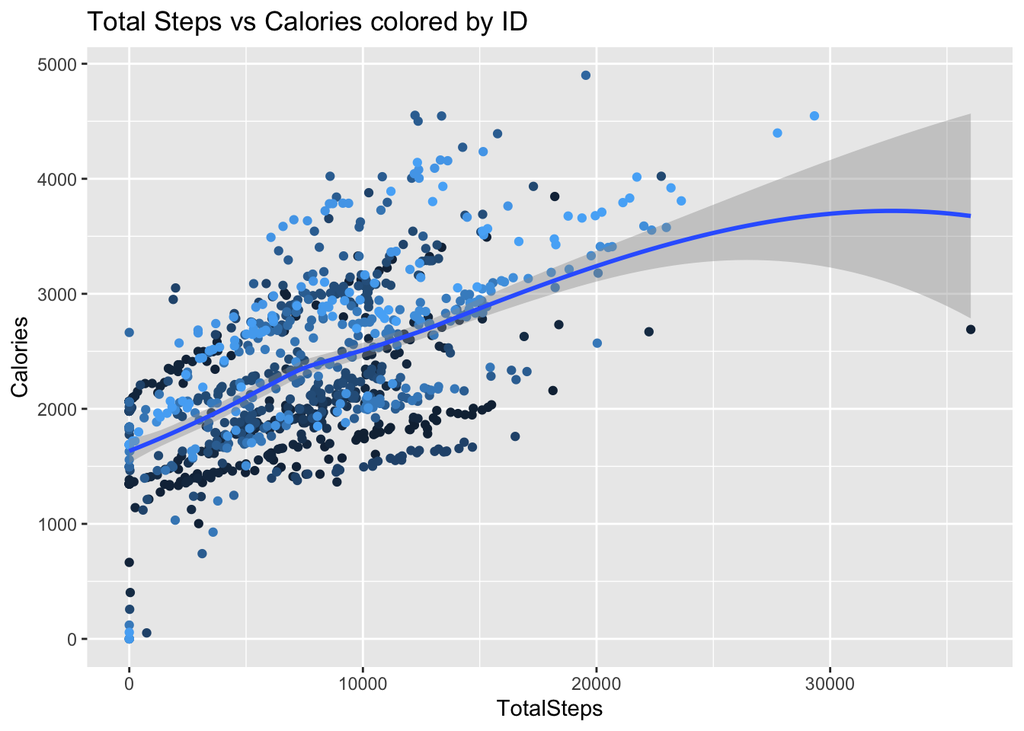

```r
ggplot(data = activity, aes(x = TotalSteps, y = Calories, color = Id)) + geom_point() + geom_smooth() + theme(legend.position='none') + labs(title = 'Total Steps vs Calories colored by ID')
```

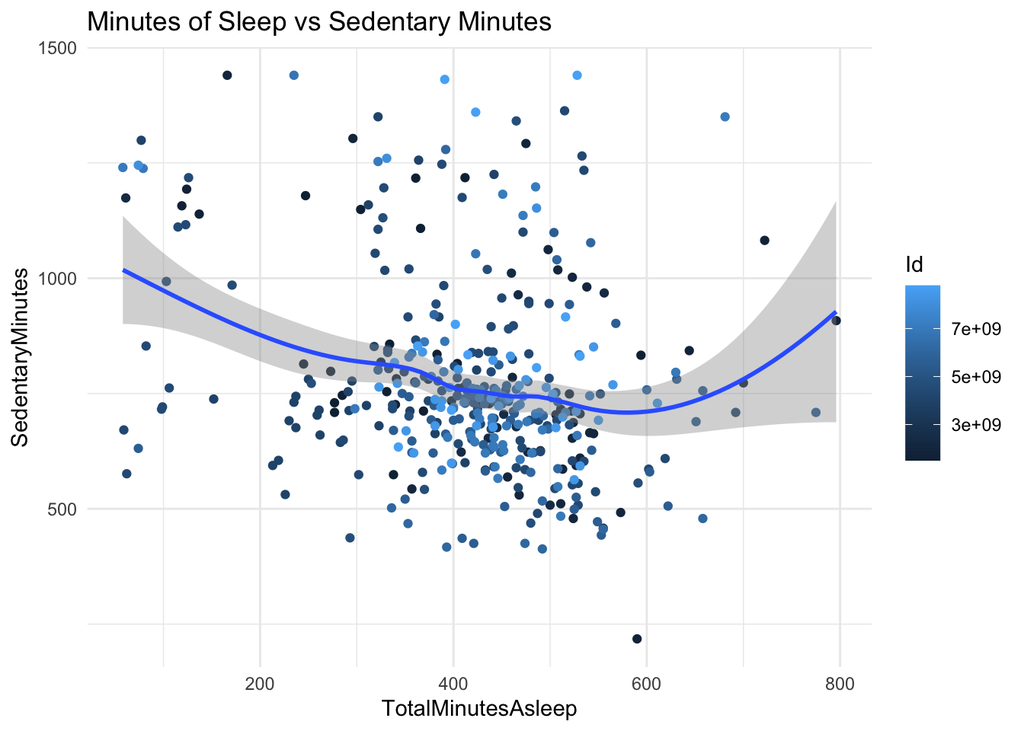

```r
ggplot(data = sleep_activity_merged, aes(x = TotalMinutesAsleep, y = SedentaryMinutes, color = Id)) + geom_point() + geom_smooth() + labs(title = 'Minutes of Sleep vs Sedentary Minutes') + theme(legend.position='none') + theme_minimal()
```

[figure not shown]

```r
ggplot(data = sleep_activity_merged, aes(x = TotalMinutesAsleep, y = FairlyActiveMinutes, color = Id)) + geom_point() + geom_smooth() + labs(title = 'Minutes of Sleep vs Sedentary Minutes') + theme(legend.position='none') + theme_minimal()
```

[figure not shown]

```r
ggplot(data = sleep_activity_merged, aes(x = TotalMinutesAsleep, y = VeryActiveMinutes, color = Id)) + geom_point() + geom_smooth() + labs(title = 'Minutes of Sleep vs Sedentary Minutes') + theme(legend.position='none') + theme_minimal()
```

```r
user_act_type <- average_daily %>%
  mutate(user_act_type = case_when(mean_daily_steps < 5000 ~ 'Sedentary',
                                   mean_daily_steps >= 5000 & mean_daily_steps < 7499 ~ 'Lightly Active',
                                   mean_daily_steps >= 7500 & mean_daily_steps < 9999 ~ 'Fairy Active',
                                   mean_daily_steps >= 10000 ~ 'Very Active'))
```

```r
percent_activity_type <- user_act_type %>%
  group_by(user_act_type) %>%
  summarize(total = n()) %>%
  mutate(totals = sum(total)) %>%
  group_by(user_act_type) %>%
  summarize(activity_type_percent = total / totals) %>%
  mutate(labels = scales::percent(activity_type_percent))

percent_activity_type$user_act_type <- factor(percent_activity_type$user_act_type,
                                              levels = c('Sedentary', 'Lightly Active', 'Fairy Active', 'Very Active'))

head(percent_activity_type)
```

```
## # A tibble: 4 × 3
##   user_act_type  activity_type_percent labels
##   <fct>                          <dbl> <chr>
## 1 Fairy Active                   0.273 27.3%
## 2 Lightly Active                 0.273 27.3%
## 3 Sedentary                      0.242 24.2%
## 4 Very Active                    0.212 21.2%
```

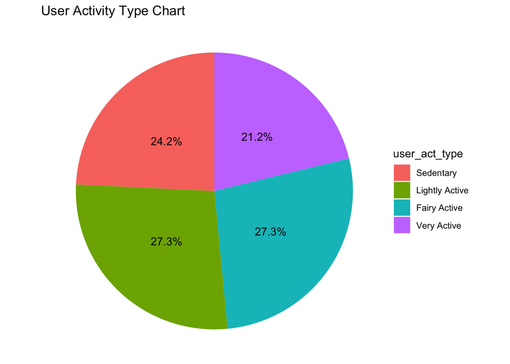

```r
# percent_activity_type
percent_activity_type %>%
  ggplot(aes(x="", y=activity_type_percent, fill=user_act_type, label=labels)) +
  geom_bar(width = 1, stat="identity") +
  coord_polar("y",start = 0) +
  theme_void() +
  # theme_bw() +
  geom_text(aes(label = labels),position =position_stack(vjust =0.5)) +
  labs(title = 'User Activity Type Chart')
```

```r
# percent_activity_type %>%
#   ggplot(aes(x="", y=activity_type_percent, fill=labels)) +
#   geom_bar(width = 1, stat="identity") +
#   coord_polar("y",start = 0)
```

## 6. Your top high-level content recommendations based on your analysis

### Conclusions and Recommendations

Based on the insights identified in the FitBit Fitness Tracker data, we can assess Bellabeat’s Marketing team and board of directors to define a Marketing strategy to comply with their mission and vision.

- 1. To start gathering data from the usage of Bellabeat’s products by asking their users permission to perform further analyzes based on much more reliable data.
- 2. Linked to the first recommendation; Bellabeat could decide to include other variables with a powerful impact on the main objective of the analysis such as: age, working flexibily (remote, hybrid, on site) as well as demographic data or a time where cravings are stronger.
- 3. As inferred from the pie chart, Sedentary lifestyle is almost 1/4 of the population, Bellabeat could think of activities within the Engineering and Marketing Departments to work together to come up with ideas to motivate people to become more active such as: hackathons.
- 4. The Bellabeat App could start showing some notifications or reminders when people have been seated or sedentary for a significant amount of time or when the heart rate starts to raise considerably or just simple random reminders to drink water or take a break and strentch.
- 5. The Bellabeat App could start to challenge users within a geographic radius to act as a motive to become more active.
- 6. Many people are on a diet to either lose or maintain their weight so, the app could start showing some healthy-tips in moments when anxiety or more cravings are most commonly identified.